# Willamette Falls Fish Passage Analysis

Conner Smith

3/3/2022

```r
knitr::opts_chunk$set(echo = TRUE, message = FALSE, warning = FALSE)

library(tidyverse)
library(here)
library(janitor)
library(knitr)
library(fable)
library(tsibble)
library(feasts)
library(lubridate)
library(thematic)
library(cowplot)
library(scales)

# Using thematic to standardize theme here

thematic::thematic_rmd()
thematic::thematic_on()
```

## **Overview**

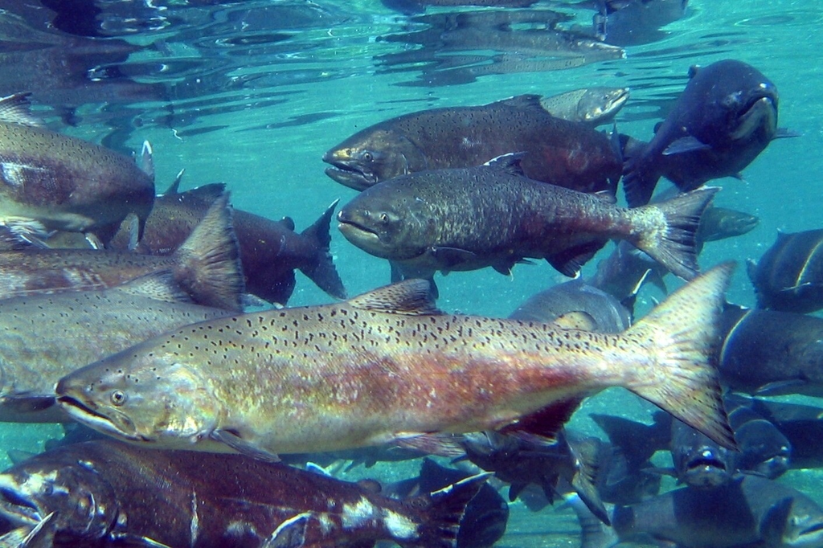

```r
# Read in the main data set

fish <- read_csv(here("data", "willamette_fish_passage.csv")) %>%
  clean_names()

# Adding image
include_graphics(here('chinook.jpg'))
```

[Source: Corvallis Advocate](https://www.corvallisadvocate.com/2020/army-corps-failed-to-protect-willamette-river-salmon-judge-rules/)

This analysis looks at fish passage data at Willamette Falls collected by the University of Washington’s Columbia Basin Research initiative. Data collection is ongoing and managed by a combination of federal, state, and tribal agencies. The tabs below include time series data, seasonal plots, and annual counts by species for fish ladder passage at Willamette Falls from 2001 to 2010.

The image below shows where the falls are located in the wider watershed.

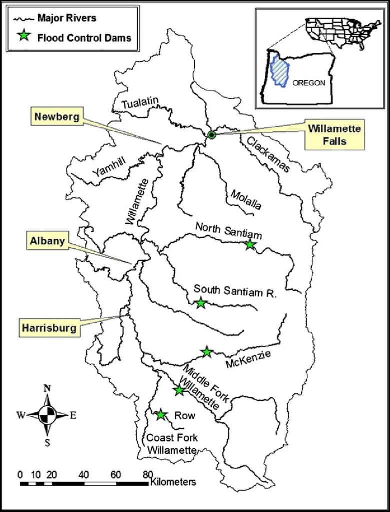

```r
include_graphics(here('watershed_map.png'))
```

[Source: Oregon Department of Fish and Wildlife](https://www.researchgate.net/publication/243963907_Pre-spawning_migration_of_adult_Pacific_lamprey_Entosphenus_tridentatus_in_the_Willamette_River_Oregon_USA)

The following image provides a schematic of the function of the locks, fish ladder, and other infrastructure at the falls.

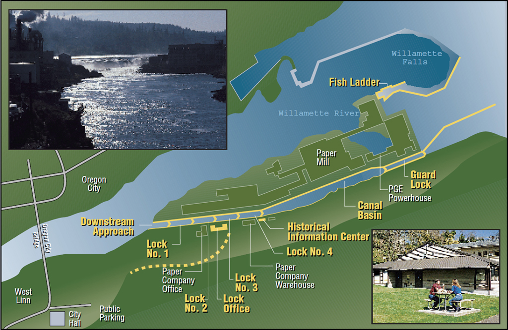

```r
include_graphics(here('falls_locks.jpg'))
```

[Source: U.S. Army Corps of Engineers](https://www.nwp.usace.army.mil/willamette/locks/)

**Data Citation** *University of Washington, Columbia Basin Research. 2010. DART Adult Passage Graphics & Text.* http://www.cbr.washington.edu/dart/query/adult_graph_text.

## **Analysis**

This analysis includes three separate tabs looking at different ways of visualizing fish passage data for three target species: Coho, Jack Coho, and Steelhead. Jack Coho return to the rivers to spawn in the same year that they smolted and are significantly smaller than the regular Coho recorded in this data set.

### **Original Time Series**

*Tab 1* shows the full time series of Willamette Falls fish passage counts for the three target species from 2001 to 2010.

```r
# Convert this to a tsibble since the 'date' column is a character

fish_ts <- fish %>%
  mutate(date = mdy(date)) %>% #Using 'lubridate::mdy' instead of 'tsibble::yearmonth'
  as_tsibble(key = NULL, index = date) %>%
  select(coho, jack_coho, steelhead) %>% #Filter for these three species
  replace_na(list(coho = 0, jack_coho = 0, steelhead = 0)) %>%

# want to make all fish appear in same column with 'pivot_longer'

  pivot_longer(cols = c(coho, jack_coho, steelhead),
               names_to = 'fish_species',
               values_to = 'passage_count') %>% #Get the names back to normal format
  mutate(fish_species = case_when(fish_species == 'coho' ~ 'Coho',
                   fish_species == 'jack_coho' ~ 'Jack Coho',
                   fish_species == 'steelhead' ~ 'Steelhead'))
```

#### **Figure 1: Counts of Fish Passage for Coho, Jack Coho, and Steelhead (2001-2010)**

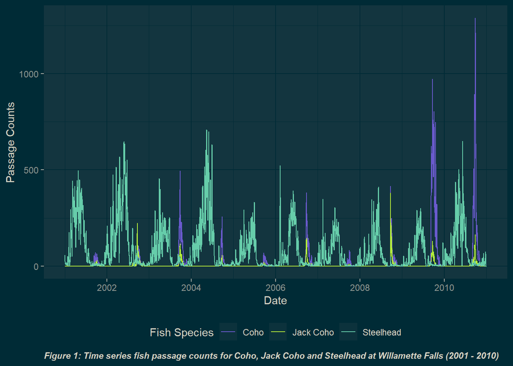

```r
# Calling the wrangled data frame into a static graph

ggplot(data = fish_ts, aes(x = date, y = passage_count)) +
  geom_line(aes(color = fish_species)) +
  scale_color_manual("Fish Species",
                     values = c('slateblue', 'olivedrab2', 'aquamarine3')) +
  labs(x = "Date", y = "Passage Counts",
       caption = "Figure 1: Time series fish passage counts for Coho, Jack Coho and Steelhead at Willamette Falls (2001 - 2010)") +
   theme(plot.caption = element_text(hjust = 0, face = "bold.italic")) +
  theme(legend.position = "bottom")
```

### **Season Plots**

*Tab 2* shows the seasonal patterns for each species across the entire time scale in order to explain some of the patterns seen in **Figure 1** in *Tab 1*.

#### **Figure 2: Seasonal Passage Counts By Species**

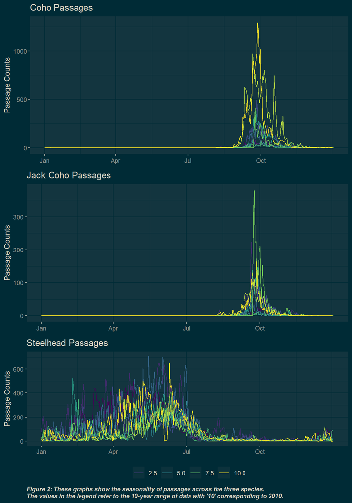

```r
coho_plot <- fish_ts %>%
  filter(fish_species == "Coho") %>%
  gg_season(y = passage_count) +
  scale_color_viridis_c() +
  labs(title = "Coho Passages", y = "Passage Counts") +
  theme(legend.position = "none") +
  theme(axis.title.x = element_blank())

jack_plot <- fish_ts %>%
  filter(fish_species == "Jack Coho") %>%
  gg_season(y = passage_count) +
  scale_color_viridis_c() +
  labs(title = "Jack Coho Passages", y = "Passage Counts") +
  theme(legend.position = "none") +
  theme(axis.title.x = element_blank())

steel_plot <- fish_ts %>%
  filter(fish_species == "Steelhead") %>%
  gg_season(y = passage_count) +
  scale_color_viridis_c() +
  labs(title = "Steelhead Passages", y = "Passage Counts",
       caption = "Figure 2: These graphs show the seasonality of passages across the three species.\nThe values in the legend refer to the 10-year range of data with '10' corresponding to 2010.") +
  theme(plot.caption = element_text(hjust = 0, face = "bold.italic")) +
  theme(legend.position = "bottom") +
  theme(axis.title.x = element_blank())

plot_grid(coho_plot,jack_plot,steel_plot,
          cols = 1, nrow = 3)
```

#### Key Takeaways

- Passages for Coho (including Jacks) are concentrated in a smaller band of months (September - November) compared to Steelhead which pass through Willamette Falls throughout the first half of the year.
- Jack Coho have the smallest passage window, which peaks in October and likely corresponds with the spawning cycles for this species.
- Higher passages for Coho and Jack Coho (displayed by lines with values on the upper end of the range outlined in the legend) correspond to the increases in passage counts after 2008 displayed in **Figure 1** in *Tab 1*.

### **Annual Count by Species**

*Tab 3* looks at the total annual passages for each of the three species across all data years. This differs from *Tab 1*, which showed daily passages.

```r
# This will do the same wrangling as in the time series tab but without converting to a tsibble

fish_counts <- fish %>%
  mutate(date = mdy(date)) %>% #lubridate
  select(coho, jack_coho, steelhead, date) %>%
  replace_na(list(coho = 0, jack_coho = 0, steelhead = 0)) %>%
  pivot_longer(cols = c(coho, jack_coho, steelhead),
               names_to = 'fish_species',
               values_to = 'passage_count') %>%
  mutate(fish_species = case_when(fish_species == 'coho' ~ "Coho",
                             fish_species == 'jack_coho' ~ "Jack Coho",
                             fish_species == 'steelhead' ~ "Steelhead")) %>%

  # Now we need to generate counts by year
  mutate(year = year(date)) %>%
  select(-date) %>% # Don;t need date anymore
  group_by(year, fish_species) %>%
  summarize(annual_counts = sum(passage_count))
```

#### **Figure 3: Annual Passage Counts by Species (2001-2010)**

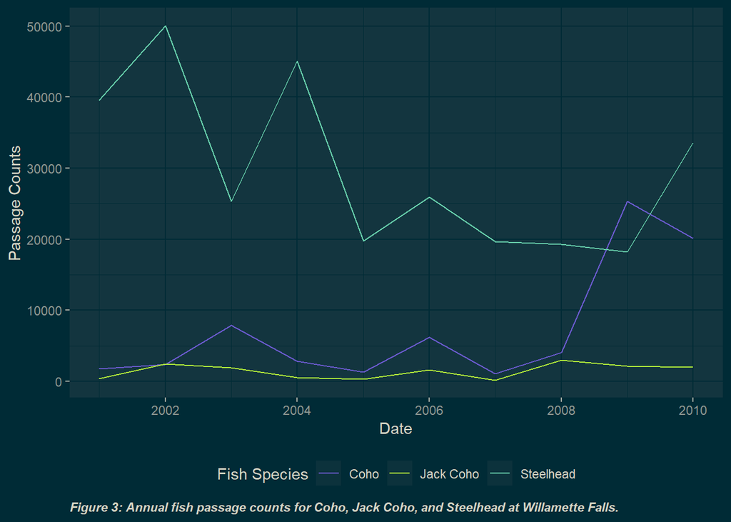

```r
ggplot(data = fish_counts, aes(x = year, y = annual_count)) +
  geom_line(aes(x = year, y = annual_counts, color = fish_species)) +
  scale_x_continuous(breaks = pretty_breaks(n = 5)) +
  scale_color_manual("Fish Species",
                     values = c('slateblue', 'olivedrab2', 'aquamarine3')) +
  labs(x = "Date", y = "Passage Counts",
       caption = "Figure 3: Annual fish passage counts for Coho, Jack Coho, and Steelhead at Willamette Falls.") +
   theme(plot.caption = element_text(hjust = 0, face = "bold.italic")) +
  theme(legend.position = "bottom")
```